# R Notebook

#### About the dataset

In many developing countries, people get their drinking water from wells. Sometimes these wells are contaminated with the chemical arsenic, which when consumed in high concentrations causes skin and bladder cancer, as well as cardiovascular disease. Fortunately, in many cases people living near contaminated wells have the opportunity to get water from nearby uncontaminated wells.

In one study, several researchers measured the concentrations of arsenic in wells in a particular region of Bangladesh. They labeled wells as safe or unsafe based on the measurements. The researchers encouraged people drinking from unsafe wells to switch to safe wells. Several years later, the researchers returned to the area with the goal of seeing who had switched from unsafe to safe wells. They recorded information on a sample of 3020 individuals who had wells at their homes that were unsafe.

We address the question: what predicts why people switch wells?

#### Variables

Switch: =1 if respondent switched to a safe well, =0 if still using own unsafe well

Arsenic: amount of arsenic in well at respondent’s home (100s of micrograms per liter)  Educ: years of schooling of the head of household

Dist: distance in meters to the nearest known safe well

Assoc: =1 if any members of household are active in community organizations, =0 otherwise

```r
#analysis of arsenic in wells data
#install.packages("pROC")
library(arm)
library(pROC)
library(readr)
arsenic <- read_csv("arsenic.csv")
#arsenic = read.csv("arsenic.csv", header = T)
dim(arsenic)
```

```
[1] 3020    5
```

```r
summary(arsenic)
```

```
     switch          arsenic           dist             assoc             educ
 Min.   :0.0000   Min.   :0.510   Min.   :  0.387   Min.   :0.0000   Min.   : 0.000
 1st Qu.:0.0000   1st Qu.:0.820   1st Qu.: 21.117   1st Qu.:0.0000   1st Qu.: 0.000
 Median :1.0000   Median :1.300   Median : 36.761   Median :0.0000   Median : 5.000
 Mean   :0.5752   Mean   :1.657   Mean   : 48.332   Mean   :0.4228   Mean   : 4.828
 3rd Qu.:1.0000   3rd Qu.:2.200   3rd Qu.: 64.041   3rd Qu.:1.0000   3rd Qu.: 8.000
 Max.   :1.0000   Max.   :9.650   Max.   :339.531   Max.   :1.0000   Max.   :17.000
```

Switch (Mean is percent valures equal 1) , 57% are 1’s

Some poor soul has arsenic at 9.6, mean around 1.66

Deinitely have dummy variable for association, maybe also for education— a lot of categories, so may need to collapse some when look at education.

Some large values that could be influential points— ie distance, or could also look at adding a log to tighten it up and pull it in

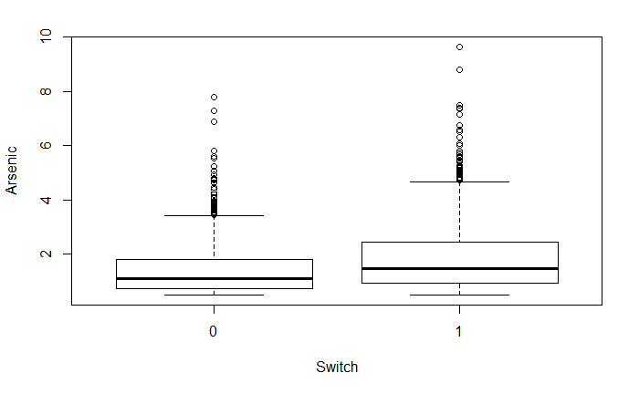

```r
#let's do some exploratory data analysis
boxplot(arsenic~switch, data = arsenic, xlab = "Switch", ylab = "Arsenic")
```

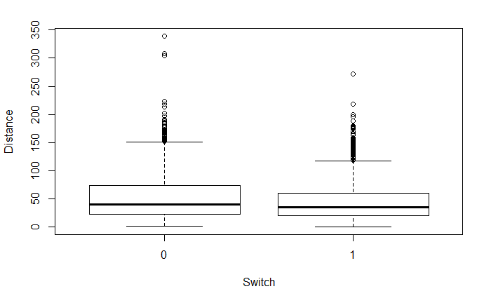

```r
boxplot(dist~switch, data = arsenic, xlab = "Switch", ylab = "Distance")
```

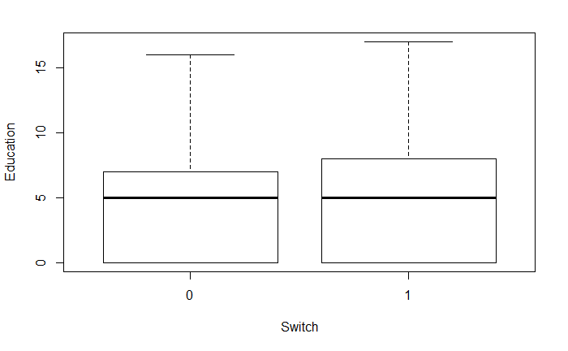

```r
boxplot(educ~switch, data = arsenic, xlab = "Switch", ylab = "Education")
```

##### Education

Doing boxplots to show an “idea” of what is going on. With switches, doesn’t look like a lot going on with just switch and education (but could have interactions etc), so don’t rule out even if doesn’t look totally important

##### Arsenic

For Arsenic, can see relationship between arsenic rates and switching.

##### Distance

Here we see a small bump up, where those who were further away were less likely to switch. Makes sense with the science- gives confidence in what going to do.

```r
# if you want to see data in tabular format
table(arsenic$assoc, arsenic$switch)
```

```
       0    1
  0  714 1029
  1  569  708
```

```r
table(arsenic$assoc, arsenic$switch)/3020
```

```
            0         1
  0 0.2364238 0.3407285
  1 0.1884106 0.2344371
```

row association, column switch Here you can see a table of associations

What it is telling you is that the pattern here is kind of the same. Marginal frequencies don’t look too useful for this. 1 are both higher than 0.

```r
#another way to see relationships of categorical variables and response -- tapply command
tapply(arsenic$switch, arsenic$assoc, mean)
```

```
        0         1
0.5903614 0.5544244
```

```r
#could do with education, too, since it is an integer variable
tapply(arsenic$switch, arsenic$educ, mean)
```

```
        0         1         2         3         4         5         6         7
0.5658043 0.3333333 0.5384615 0.5785124 0.4942529 0.5241379 0.5153846 0.6031746
        8         9        10        11        12        13        14        15
0.5857143 0.6444444 0.6850394 0.6666667 0.7414966 0.6000000 0.6250000 0.6190476
       16        17
0.6250000 1.0000000
```

```r
table(arsenic$educ)
```

```
  0   1   2   3   4   5   6   7   8   9  10  11  12  13  14  15  16  17
889   6  52 121 174 725 130 126 210  90 254  21 147   5  32  21  16   1
```

##### Association

T apply give percentage of first variable by second (come back and see this) when assoc is 0, 59% switched, when 1, 55% switched (for Assoxiation)

##### Education

Here all around 50% up to about 7, then it goes up, but stays somewhat similar above 6. (but don’t worry about small data points ie for levels 1, 17)

Might be worth thinking about this about constant until 6, then potentially another constant trend? So perhaps make a binary?

This could be an explority to look at relationship between predicted probabilities and percent 1s, see if a pattern – using Bins or code below

#### For categorical predictors, look at percentages of ones

in outcome variable for each level.  For continuous predictors, consider following steps:  Break predictor into 1o equally sized, ordered groups (or even more groups if lots of data)  Compute percentages of ones in outcome variable for each group.  See if there is a pattern, e.g., quadratic

R code for categorizing continuous predictors Option 1: Use the binnedplot command: binnedplot(y=arsenic$switch, x = arsenic$dist) Option 2: Do it manually First install and load the Hmisc package. #create deciles using the cut2 command decilesage = cut2(arsenic$dist, g=10) #now compute the % of ones in each group tapply(arsenic$switch, decilesage, mean)

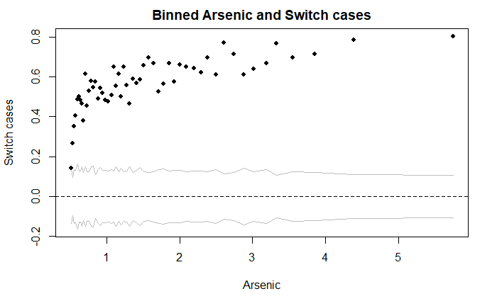

```r
#remember that there are few observations at some of these values of the predictors, so the percentages
# need to be considered in the context of large uncertainties.  but, this does suggest a change at 7 years of education.
#we might consider a dummy variable for 7 or higher rather than a linear term... something to try later.
#let's look at binnedplots of continuous predictors versus switch
#ignore the SD lines in these plots -- they are only relevant when plotting binned residuals versus the predicted probabilities
binnedplot(arsenic$arsenic, y=arsenic$switch, xlab = "Arsenic", ylab = "Switch cases", main = "Binned Arsenic and Switch cases")
```

Kinda asemptotes, so possibly a log trend —- may consider log of arsenic

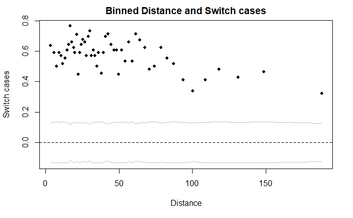

```r
#note the quickly increasing trend followed by flattening. Probability does not start to decrease, though, so
#unlikely we'd want a quadratic term.  We would expect some flattening with a linear trend.
binnedplot(arsenic$dist, y=arsenic$switch, xlab = "Distance", ylab = "Switch cases", main = "Binned Distance and Switch cases")
```

```r
#no obvious transformation suggested.
```

This one is more “vanilla”, doesn’t seem to asemptote,so maybe linear

#### Exploration Summmary

so looks like log arsenic, regular distance, possibly binary education

```r
#let's try a logistic regression that has a main effect for every variable and linear predictors
#begin by centering the continuous predictors (we'll leave educ alone since we might use a dummy variable later)
arsenic$arsenic.c = arsenic$arsenic - mean(arsenic$arsenic)
arsenic$dist.c = arsenic$dist - mean(arsenic$dist)
arsreg1 = glm(switch ~ arsenic.c + dist.c + assoc + educ, data = arsenic, family = binomial)
summary(arsreg1)
```

```
Call:
glm(formula = switch ~ arsenic.c + dist.c + assoc + educ, family = binomial,
    data = arsenic)

Deviance Residuals:
    Min       1Q   Median       3Q      Max
-2.5942  -1.1976   0.7541   1.0632   1.6739

Coefficients:
             Estimate Std. Error z value Pr(>|z|)
(Intercept)  0.184004   0.068243   2.696  0.00701 **
arsenic.c    0.467022   0.041602  11.226  < 2e-16 ***
dist.c      -0.008961   0.001046  -8.569  < 2e-16 ***
assoc       -0.124300   0.076966  -1.615  0.10631
educ         0.042447   0.009588   4.427 9.55e-06 ***
---
Signif. codes:  0 ‘***’ 0.001 ‘**’ 0.01 ‘*’ 0.05 ‘.’ 0.1 ‘ ’ 1

(Dispersion parameter for binomial family taken to be 1)

    Null deviance: 4118.1  on 3019  degrees of freedom
Residual deviance: 3907.8  on 3015  degrees of freedom
AIC: 3917.8

Number of Fisher Scoring iterations: 4
```

As simple a model as can have if for these data.

does seem that arsenic is a strong predictor, z value of 11 same with distance, with 10 meter odds association, not much education can see moving in trend direction we expected

sample interpretation: effect of arsenic, holding constant relationship with distance, association, eductation, we expect…

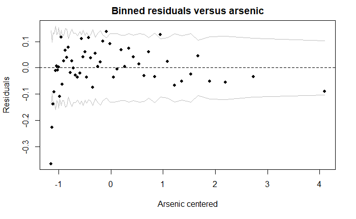

```r
####model diagnostics
##binned residual plots
# compute raw residuals
rawresid1 = arsenic$switch - fitted(arsreg1)
binnedplot(x=arsenic$arsenic.c, y = rawresid1, xlab = "Arsenic centered", ylab = "Residuals", main = "Binned residuals versus arsenic")
```

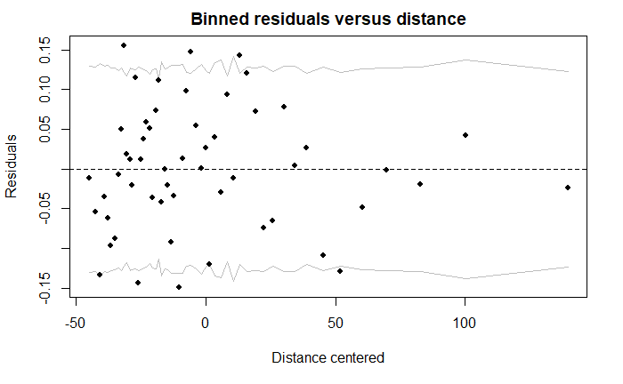

```r
#note the up-then-down nature of the binned plot! we might try a transformation, say log.
binnedplot(x=arsenic$dist.c, y = rawresid1, xlab = "Distance centered", ylab = "Residuals", main = "Binned residuals versus distance")
```

```r
#not as much of a trend, really.
```

```r
#let's look at average residuals by education using the tapply command
tapply(rawresid1, arsenic$educ, mean)
```

```
          0           1           2           3           4           5           6
 0.03078444 -0.17580343  0.01773854  0.03546977 -0.04092430 -0.05682847 -0.08329009
          7           8           9          10          11          12          13
 0.01353330 -0.01346264  0.03116807  0.06031244  0.02255998  0.09135557 -0.04661402
         14          15          16          17
-0.02873480 -0.06352081 -0.07006512  0.32439065
```

```r
#unremarkable -- although, many average residuals for educ < 7 are negative and for educ > 7 are positive (at least where the sample size for the education level is non-negligible
#we could try the dummy variable split....
```

education 0, fit well; at 1, not so good but remember smaller sample there.

Not GREAT, but not terrible, prefer less than .07 or .06

```r
tapply(rawresid1, arsenic$assoc, mean)
```

```
            0             1
 7.378378e-17 -4.261137e-17
```

```r
#nothing helpful here...
```

Doesn’t get better than that!

binned residuals look great often when have dummy variables

```r
#let's do the confusion matrix with .5 threshold and with .58 threshold (marginal percentage in data)
threshold = 0.5
table(arsenic$switch, arsreg1$fitted > threshold)
```

```
    FALSE TRUE
  0   470  813
  1   346 1391
```

```r
threshold = 0.58
table(arsenic$switch, arsreg1$fitted > threshold)
```

```
    FALSE TRUE
  0   877  406
  1   829  908
```

.5 is default , can se not bad, lot on diag but def on counter diag too .58 is marginal frequency of y– see a lot of changes!

so things are happening between .5 and .58 and may be able to have room to improve model

```
Call:
roc.default(response = arsenic$switch, predictor = fitted(arsreg1),     plot = T, legacy.axes = T)

Data: fitted(arsreg1) in 1283 controls (arsenic$switch 0) < 1737 cases (arsenic$switch 1).
Area under the curve: 0.6491
```

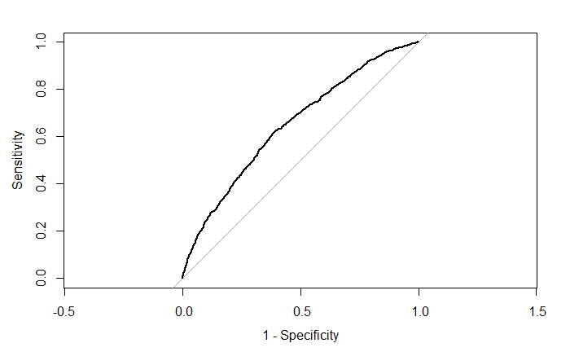

```r
#huge difference!  seems a lot of predicted probabilities are in the .5 yo .58  range, so cutoff matters.
#either way, we have large off-diagonal numbers.  let's see if we can't improve the model.
#look at ROC curve
roc(arsenic$switch, fitted(arsreg1), plot=T, legacy.axes=T)
```

only thing that really jumped out was log of arsenic, so look at that and then do mean centering

```r
#pretty tight to the line -- not a strongly predictive logistic regression
#based on binned residual plot, let's try a log of arsenic to start with, and see what happens.
arsenic$logarsenic = log(arsenic$arsenic)
arsenic$logarsenic.c = arsenic$logarsenic - mean(arsenic$logarsenic)
arsreg2 = glm(switch ~ logarsenic.c + dist.c + assoc + educ, data = arsenic, family = binomial)
summary(arsreg2)
```

```
Call:
glm(formula = switch ~ logarsenic.c + dist.c + assoc + educ,
    family = binomial, data = arsenic)

Deviance Residuals:
    Min       1Q   Median       3Q      Max
-2.0742  -1.1760   0.7369   1.0382   1.8044

Coefficients:
              Estimate Std. Error z value Pr(>|z|)
(Intercept)   0.177534   0.068601   2.588  0.00966 **
logarsenic.c  0.886959   0.068901  12.873  < 2e-16 ***
dist.c       -0.009791   0.001061  -9.227  < 2e-16 ***
assoc        -0.123718   0.077431  -1.598  0.11009
educ          0.042740   0.009656   4.426 9.59e-06 ***
---
Signif. codes:  0 ‘***’ 0.001 ‘**’ 0.01 ‘*’ 0.05 ‘.’ 0.1 ‘ ’ 1

(Dispersion parameter for binomial family taken to be 1)

    Null deviance: 4118.1  on 3019  degrees of freedom
Residual deviance: 3875.6  on 3015  degrees of freedom
AIC: 3885.6

Number of Fisher Scoring iterations: 4
```

see value has bumped up some, so going in right direction, everything else more or less the same.

may have helped some with arsenic, but check fit…

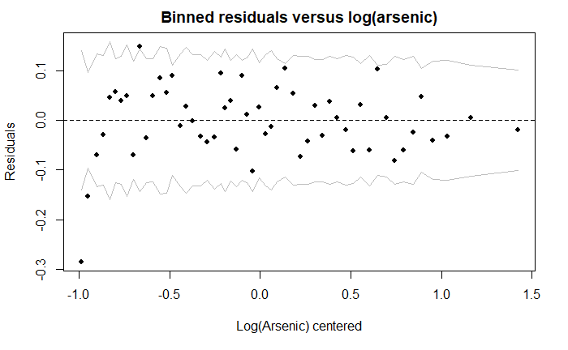

```r
#back to diagnostics
rawresid2 = arsenic$switch - fitted(arsreg2)
binnedplot(x=arsenic$logarsenic.c, y = rawresid2, xlab = "Log(Arsenic) centered", ylab = "Residuals", main = "Binned residuals versus log(arsenic)")
```

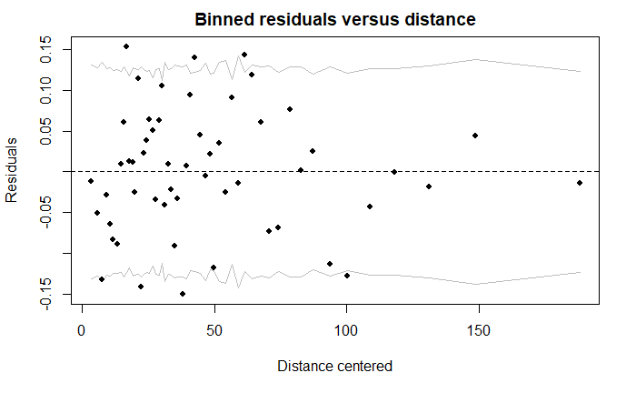

```r
#seems to have helped some!
binnedplot(x=arsenic$dist, y = rawresid2, xlab = "Distance centered", ylab = "Residuals", main = "Binned residuals versus distance")
```

```r
#still not as much of a trend.
```

Looks like one point is way off, and this is a limitation of my model– model fits pretty well except at the really small values of arsenic, and number of people who switchedd was smaller than expected at these values.

```r
tapply(rawresid2, arsenic$educ, mean)
```

```
          0           1           2           3           4           5           6
 0.03011936 -0.16581613  0.01469886  0.04148189 -0.03630364 -0.05736013 -0.08543816
          7           8           9          10          11          12          13
 0.01101884 -0.01439338  0.03439054  0.06002044  0.02607046  0.09300187 -0.03026982
         14          15          16          17
-0.02749367 -0.06980890 -0.08154564  0.32202976
```

```r
#similar pattern as before for education.
```

```r
#let's do the confusion matrix
threshold = 0.5
table(arsenic$switch, arsreg2$fitted > threshold)
```

```
    FALSE TRUE
  0   534  749
  1   388 1349
```

```r
threshold = 0.58
table(arsenic$switch, arsreg2$fitted > threshold)
```

```
    FALSE TRUE
  0   861  422
  1   744  993
```

Can see helped some on diagonals

```
Call:
roc.default(response = arsenic$switch, predictor = fitted(arsreg2),     plot = T, legacy.axes = T)

Data: fitted(arsreg2) in 1283 controls (arsenic$switch 0) < 1737 cases (arsenic$switch 1).
Area under the curve: 0.6596
```

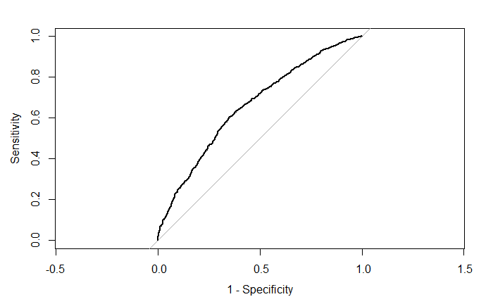

```r
#we seem to have improved at .58 threshold (although not by much, really).
#look at ROC curve
roc(arsenic$switch, fitted(arsreg2), plot=T, legacy.axes=T)
```

Plot looks more or less the same. Gained a little bit of predictive accuracy .64 to .65 AUC Not huge, but why not ! make best you can

What about education- binary split help?

```r
#not much difference from last curve really, although a little more prediction accuracy
#let's see what happens if we make education a binary split at 7.
arsenic$educg6 = rep(0, 3020)
arsenic$educg6[arsenic$educ > 6] = 1
arsreg3 = glm(switch ~ logarsenic.c + dist.c + assoc + educg6, data = arsenic, family = binomial)
summary(arsreg3)
```

```
Call:
glm(formula = switch ~ logarsenic.c + dist.c + assoc + educg6,
    family = binomial, data = arsenic)

Deviance Residuals:
    Min       1Q   Median       3Q      Max
-2.1018  -1.1645   0.7179   1.0328   1.8690

Coefficients:
              Estimate Std. Error z value Pr(>|z|)
(Intercept)   0.231559   0.056812   4.076 4.58e-05 ***
logarsenic.c  0.893435   0.069053  12.938  < 2e-16 ***
dist.c       -0.009785   0.001063  -9.204  < 2e-16 ***
assoc        -0.119562   0.077651  -1.540    0.124
educg6        0.498476   0.085060   5.860 4.62e-09 ***
---
Signif. codes:  0 ‘***’ 0.001 ‘**’ 0.01 ‘*’ 0.05 ‘.’ 0.1 ‘ ’ 1

(Dispersion parameter for binomial family taken to be 1)

    Null deviance: 4118.1  on 3019  degrees of freedom
Residual deviance: 3860.4  on 3015  degrees of freedom
AIC: 3870.4

Number of Fisher Scoring iterations: 4
```

Kinda see sort of made a difference, z 4.4 to z 5.8– would probably talk about the science and see if a threshold makes sense in real life, if so, keep it.

```
Call:
roc.default(response = arsenic$switch, predictor = fitted(arsreg3),     plot = T, legacy.axes = T)

Data: fitted(arsreg3) in 1283 controls (arsenic$switch 0) < 1737 cases (arsenic$switch 1).
Area under the curve: 0.6632
```

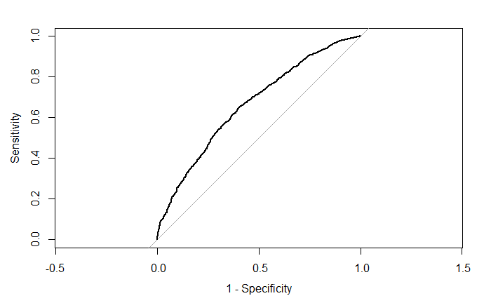

```r
#this seems to have helped the significance of education, and it is scientifically plausible.  let's keep it!
#should go through binned residuals again to make sure this did not worsen model fit.  It did not.
#look at new roc curve to see if it is any better
roc(arsenic$switch, fitted(arsreg3), plot=T, legacy.axes=T)
```

```r
# it is a little better, with a higher area under the curve (AUC = .6632).  let's keep this model.
```

AUC .6632 pretty good- let’s keep it and move on!

```r
exp(confint.default(arsreg3))
```

```
                 2.5 %    97.5 %
(Intercept)  1.1277321 1.4090408
logarsenic.c 2.1342053 2.7976384
dist.c       0.9882011 0.9923278
assoc        0.7620404 1.0331705
educg6       1.3934210 1.9448603
```

```r
exp(.498)
```

```
[1] 1.645427
```

```r
exp(-.12)
```

```
[1] 0.8869204
```

```r
exp(-.0097*10)
```

```
[1] 0.907556
```

```r
exp(confint.default(arsreg3)*10)
```

```
                    2.5 %       97.5 %
(Intercept)  3.327051e+00 3.084862e+01
logarsenic.c 1.960478e+03 2.937080e+04
dist.c       8.880822e-01 9.258736e-01
assoc        6.603586e-02 1.385861e+00
educg6       2.759457e+01 7.742552e+02
```

fore every 10 meters, in dist, expect odds of switiing to increase by multiplicative factor of .90 (so actually decrease by about 10%)

To interpret…use math to eliminate log in interpretation….same as we did before, get if mult predict by constant, then expect odds should change by factor of e to b1logc

Next, think about interactions.

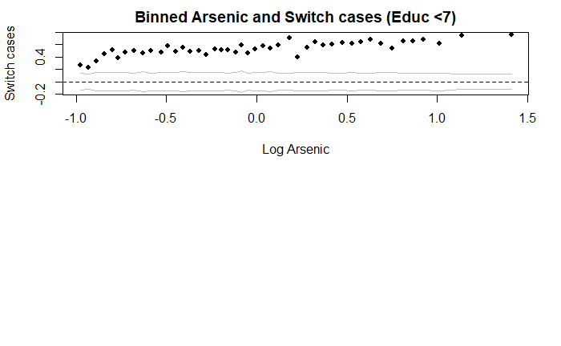

```r
### interactions in logistic regression
#scientifically, it is plausible to think that there might be interactions among all the variables and arsenic, or among education and distance.
#let's add the interactions to see if any stand out.
#first, here is a way to explore the data for interactions using the binnedplot command
#lets set up the graphics device to show two plots side by side
par(mfcol=c(2,1))
#first plot for educg6 = 0
binnedplot(arsenic$logarsenic.c[arsenic$educg6==0], y=arsenic$switch[arsenic$educg6==0], xlab = "Log Arsenic", ylab = "Switch cases", main = "Binned Arsenic and Switch cases (Educ <7)")
#next the plot for educg6 = 1
binnedplot(arsenic$logarsenic.c[arsenic$educg6==1], y=arsenic$switch[arsenic$educg6==1], xlab = "Log Arsenic", ylab = "Switch cases", main = "Binned Arsenic and Switch cases (Educ > 6)")
```

[output not shown]

A little bit of a hook on left/lower end, so look at bc scientifically of interest.

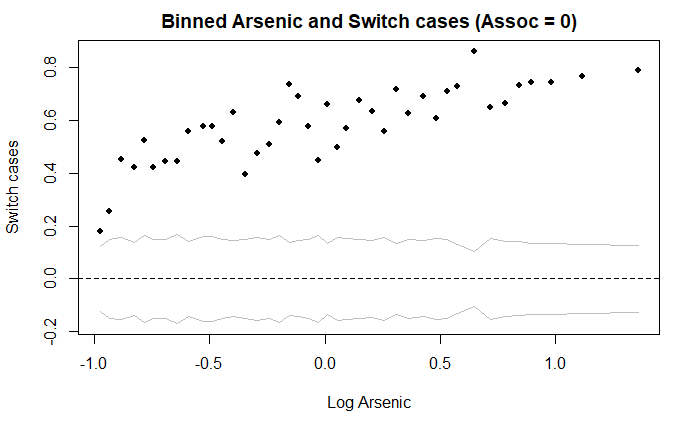

```r
#we are looking for differences in the trend.  not strong ones, except possibly at low levels of arsenic.
#I will include an interaction based on scientific arguments in favor of an interaction effect, but I am not expecting a very strong interaction effect based on this plot.
#let's try for association and arsenic
#first plot for assoc = 0
binnedplot(arsenic$logarsenic.c[arsenic$assoc==0], y=arsenic$switch[arsenic$assoc==0], xlab = "Log Arsenic", ylab = "Switch cases", main = "Binned Arsenic and Switch cases (Assoc = 0)")
```

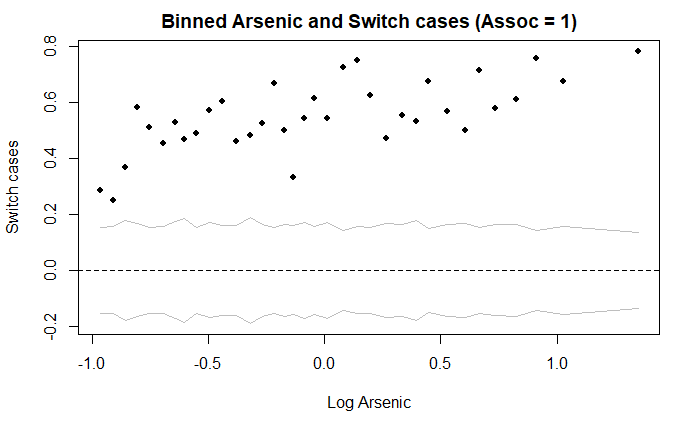

```r
#next the plot for assoc = 1
binnedplot(arsenic$logarsenic.c[arsenic$assoc==1], y=arsenic$switch[arsenic$assoc==1], xlab = "Log Arsenic", ylab = "Switch cases", main = "Binned Arsenic and Switch cases (Assoc = 1)")
```

Really not a lot of difference.

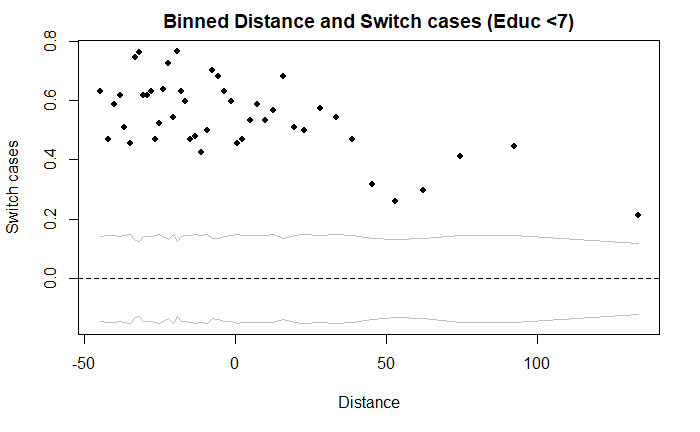

```r
#even less reason to suspect an interaction effect from this plot.
#how about distance and education?
#first plot for educg6 = 0
binnedplot(arsenic$dist.c[arsenic$educg6==0], y=arsenic$switch[arsenic$educg6==0], xlab = "Distance", ylab = "Switch cases", main = "Binned Distance and Switch cases (Educ <7)")
```

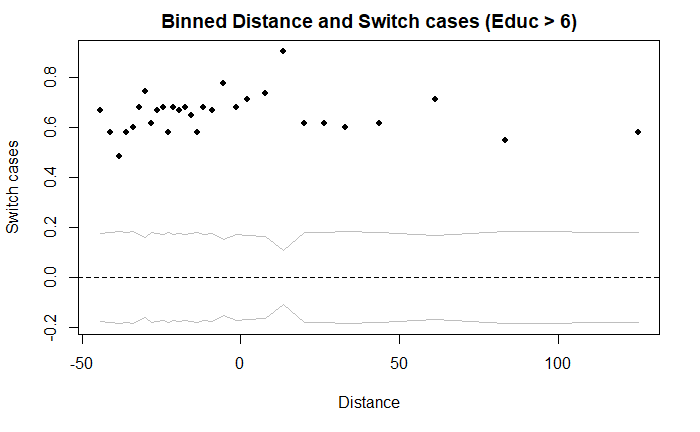

```r
#next the plot for educg6 = 1
binnedplot(arsenic$dist.c[arsenic$educg6==1], y=arsenic$switch[arsenic$educg6==1], xlab = "Distance", ylab = "Switch cases", main = "Binned Distance and Switch cases (Educ > 6)")
```

This is really something to look at. Looks like education combats/counters distance deterrant. Scientific basis, so want to follow up with this one.

```r
#this is a little more interesting -- we see one plot flatten and the other decrease.  here an interaction might be useful.
#let's first try the model with all the interactions
arsreg4 = glm(switch ~ dist.c*educg6  + logarsenic.c * (assoc + educg6), data = arsenic, family = binomial)
summary(arsreg4)
```

```
Call:
glm(formula = switch ~ dist.c * educg6 + logarsenic.c * (assoc +
    educg6), family = binomial, data = arsenic)

Deviance Residuals:
   Min      1Q  Median      3Q     Max
-2.235  -1.153   0.701   1.036   2.025

Coefficients:
                     Estimate Std. Error z value Pr(>|z|)
(Intercept)          0.239731   0.057376   4.178 2.94e-05 ***
dist.c              -0.012636   0.001340  -9.430  < 2e-16 ***
educg6               0.526891   0.087248   6.039 1.55e-09 ***
logarsenic.c         0.944550   0.100337   9.414  < 2e-16 ***
assoc               -0.141440   0.078256  -1.807 0.070698 .
dist.c:educg6        0.008512   0.002311   3.683 0.000231 ***
logarsenic.c:assoc  -0.241134   0.133072  -1.812 0.069978 .
educg6:logarsenic.c  0.244610   0.158278   1.545 0.122238
---
Signif. codes:  0 ‘***’ 0.001 ‘**’ 0.01 ‘*’ 0.05 ‘.’ 0.1 ‘ ’ 1

(Dispersion parameter for binomial family taken to be 1)

    Null deviance: 4118.1  on 3019  degrees of freedom
Residual deviance: 3835.6  on 3012  degrees of freedom
AIC: 3851.6

Number of Fisher Scoring iterations: 4
```

```r
exp(-.0125*10) # <6, inc 10 meters
```

```
[1] 0.8824969
```

```r
exp((-.0126+.0085)*10) # >6, inc 10 meters
```

```
[1] 0.9598291
```

```r
exp(0.527)
```

```
[1] 1.693843
```

dist and education– strongly significant, slope we expected, a little positive. other slopes look similar to slopes we expected

-.012 :if inc dist by 1 meter, for people less than 6 yrs education (baseline cat), the log odds change by -.012

if inc dist 10 meters, for people less than 6 yrs education, the odds of switching go down by .88 (88% what were)

0.527: with everything else constant (avg log ars, avg dist) the effect of less than 7 to 7 or more years of education, the odds increase by e^0.527, or 1.69

.526 + 10*.008 5 if log ars constant, but increase by 10 meters, (double check this)

overall effect of association- if want to see if important, try to model with variable in and out— anova/nested f test in linear regression, but called change in deviance test for logistic Regression

##### Comparing nested models in logistic regression

In linear regression we use the nested F-test to compare two nested models. In logistic regression we use the change in deviance test. Expression for change in deviance on next slide for those interested, but formula not essential for our course. Can use the anova command in R! Hooray!!

##### Change in deviance test (see slides with formulas)

```r
#these collectively look sort of useful, especially the education ones!
#change in deviance tests to see if the full set of interactions are useful.
anova(arsreg4, arsreg3, test= "Chisq")
```

```
Analysis of Deviance Table

Model 1: switch ~ dist.c * educg6 + logarsenic.c * (assoc + educg6)
Model 2: switch ~ logarsenic.c + dist.c + assoc + educg6
  Resid. Df Resid. Dev Df Deviance  Pr(>Chi)
1      3012     3835.6
2      3015     3860.4 -3  -24.781 1.715e-05 ***
---
Signif. codes:  0 ‘***’ 0.001 ‘**’ 0.01 ‘*’ 0.05 ‘.’ 0.1 ‘ ’ 1
```

Can see if significant (assoc vs no association in equation)

Is highly significant- chance of getting 24 or more due to chance is really unlikely. p value really small.

```r
#the whole group of interactions is significant.  let's just test if the distance interaction is useful, given the other two in the model.
arsreg4a= glm(switch ~ logarsenic.c * (assoc + educg6), data = arsenic, family = binomial)
summary(arsreg4a)
```

```
Call:
glm(formula = switch ~ logarsenic.c * (assoc + educg6), family = binomial,
    data = arsenic)

Deviance Residuals:
    Min       1Q   Median       3Q      Max
-2.1747  -1.1819   0.7599   1.0704   1.3877

Coefficients:
                    Estimate Std. Error z value Pr(>|z|)
(Intercept)          0.22227    0.05610   3.962 7.43e-05 ***
logarsenic.c         0.72764    0.09404   7.737 1.02e-14 ***
assoc               -0.12880    0.07674  -1.678  0.09328 .
educg6               0.53842    0.08641   6.231 4.63e-10 ***
logarsenic.c:assoc  -0.24485    0.13000  -1.884  0.05963 .
logarsenic.c:educg6  0.39360    0.15034   2.618  0.00884 **
---
Signif. codes:  0 ‘***’ 0.001 ‘**’ 0.01 ‘*’ 0.05 ‘.’ 0.1 ‘ ’ 1

(Dispersion parameter for binomial family taken to be 1)

    Null deviance: 4118.1  on 3019  degrees of freedom
Residual deviance: 3939.2  on 3014  degrees of freedom
AIC: 3951.2

Number of Fisher Scoring iterations: 4
```

```r
anova(arsreg4a, arsreg4, test= "Chisq")
```

```
Analysis of Deviance Table

Model 1: switch ~ logarsenic.c * (assoc + educg6)
Model 2: switch ~ dist.c * educg6 + logarsenic.c * (assoc + educg6)
  Resid. Df Resid. Dev Df Deviance  Pr(>Chi)
1      3014     3939.2
2      3012     3835.6  2   103.61 < 2.2e-16 ***
---
Signif. codes:  0 ‘***’ 0.001 ‘**’ 0.01 ‘*’ 0.05 ‘.’ 0.1 ‘ ’ 1
```

This is test jerry prefers we use to check significance (as opposed to z test – Pr(>|z|))

```r
#looks like the interaction with distance and education is useful.
#let's make our final model (arsreg5) be the one with all the interaction effects.
arsreg5 = glm(switch ~ dist.c*educg6  + logarsenic.c * (assoc + educg6), data = arsenic, family = binomial)
summary(arsreg5)
```

```
Call:
glm(formula = switch ~ dist.c * educg6 + logarsenic.c * (assoc +
    educg6), family = binomial, data = arsenic)

Deviance Residuals:
   Min      1Q  Median      3Q     Max
-2.235  -1.153   0.701   1.036   2.025

Coefficients:
                     Estimate Std. Error z value Pr(>|z|)
(Intercept)          0.239731   0.057376   4.178 2.94e-05 ***
dist.c              -0.012636   0.001340  -9.430  < 2e-16 ***
educg6               0.526891   0.087248   6.039 1.55e-09 ***
logarsenic.c         0.944550   0.100337   9.414  < 2e-16 ***
assoc               -0.141440   0.078256  -1.807 0.070698 .
dist.c:educg6        0.008512   0.002311   3.683 0.000231 ***
logarsenic.c:assoc  -0.241134   0.133072  -1.812 0.069978 .
educg6:logarsenic.c  0.244610   0.158278   1.545 0.122238
---
Signif. codes:  0 ‘***’ 0.001 ‘**’ 0.01 ‘*’ 0.05 ‘.’ 0.1 ‘ ’ 1

(Dispersion parameter for binomial family taken to be 1)

    Null deviance: 4118.1  on 3019  degrees of freedom
Residual deviance: 3835.6  on 3012  degrees of freedom
AIC: 3851.6

Number of Fisher Scoring iterations: 4
```

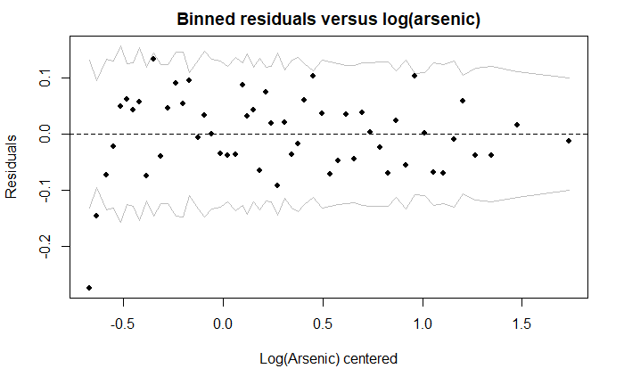

```r
#let's do the binned residual plots with this perhaps final model one more time!
rawresid5 = arsenic$switch - fitted(arsreg5)
binnedplot(x=arsenic$logarsenic, y = rawresid5, xlab = "Log(Arsenic) centered", ylab = "Residuals", main = "Binned residuals versus log(arsenic)")
```

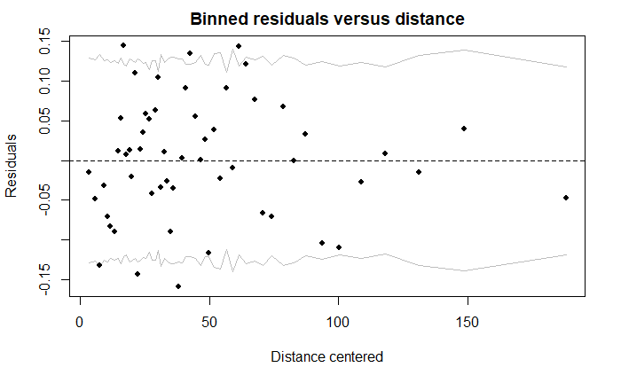

```r
binnedplot(x=arsenic$dist, y = rawresid5, xlab = "Distance centered", ylab = "Residuals", main = "Binned residuals versus distance")
```

```r
tapply(rawresid5, arsenic$educ, mean)
```

```
           0            1            2            3            4            5
 0.017671046 -0.184747551  0.020709012  0.055227737 -0.011367015 -0.020980185
           6            7            8            9           10           11
-0.039784651 -0.044420884 -0.059937169 -0.005441617  0.028355066  0.030752205
          12           13           14           15           16           17
 0.090512698  0.030082323 -0.018010434 -0.059676840 -0.075358808  0.405109513
```

for binned residuals versus log(arsenic), still off for really small values- so may not be a reliable model for those values- just a limitation of the model, not much you can do.

for distance, pretty much as good as we will get, not more you can really do.

```r
#a little more diversity with education, so that seems to have helped.
#still a little trouble fitting small log arsenic, but not too much more we can do....  go with this model!
#let's do the confusion matrix
threshold = 0.5
table(arsenic$switch, arsreg5$fitted > threshold)
```

```
    FALSE TRUE
  0   584  699
  1   385 1352
```

```r
threshold = 0.58
table(arsenic$switch, arsreg5$fitted > threshold)
```

```
    FALSE TRUE
  0   855  428
  1   731 1006
```

```
Call:
roc.default(response = arsenic$switch, predictor = fitted(arsreg5),     plot = T, legacy.axes = T)

Data: fitted(arsreg5) in 1283 controls (arsenic$switch 0) < 1737 cases (arsenic$switch 1).
Area under the curve: 0.6707
```

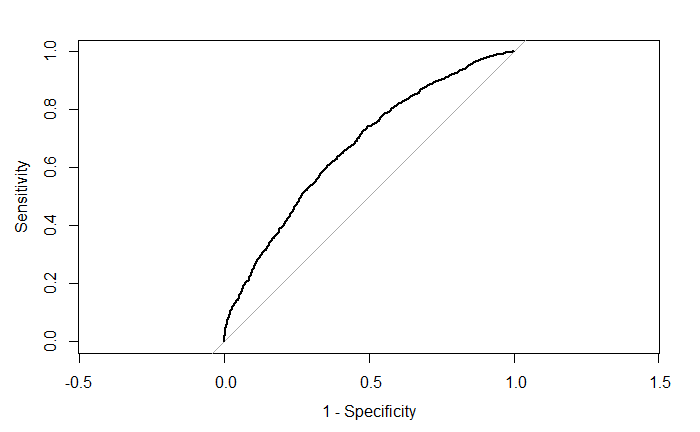

```r
#still not moving much.... the model can predict only so well
#ROC curve...
roc(arsenic$switch, fitted(arsreg5), plot=T, legacy.axes=T)
```

A little better, not much, but like bc makes sense interpretation and science wise, and also a bit better according to data too.

```r
#a little better still... but we really aren't gaining a whole lot.  this is about as
#good as we are going to get with only these variables, apparently.
###model interpretations
confint.default(arsreg5)   #on log odds scale
```

```
                           2.5 %      97.5 %
(Intercept)          0.127275445  0.35218663
dist.c              -0.015262809 -0.01000979
educg6               0.355888793  0.69789299
logarsenic.c         0.747892881  1.14120739
assoc               -0.294818786  0.01193794
dist.c:educg6        0.003981547  0.01304168
logarsenic.c:assoc  -0.501950404  0.01968261
educg6:logarsenic.c -0.065608872  0.55482881
```

```r
exp(confint.default(arsreg5))   #on odds scale
```

```
                        2.5 %    97.5 %
(Intercept)         1.1357298 1.4221739
dist.c              0.9848531 0.9900401
educg6              1.4274488 2.0095142
logarsenic.c        2.1125439 3.1305459
assoc               0.7446665 1.0120095
dist.c:educg6       1.0039895 1.0131271
logarsenic.c:assoc  0.6053488 1.0198776
educg6:logarsenic.c 0.9364971 1.7416428
```

Pretty tight confidence interval for dist.c

##### Interpretations

We have the same general interpretation as in the linear regression model: “holding all else constant, a change of 1 unit in x is expected to increase the log-odds of a success in y by .,..”  For categorical predictors, use the odds ratio interpretation: exponentiate the estimate and CI.

For numerical predictors or when variables involved in interactions, plot the predicted probabilities versus the predictor values.

Final model: interactions log(arsenic) and association, log arsenic and educg6, and distance and educg6.

Interpretations: Direct: For individuals who are not part of associations and have less than 7 years of education, the log odds of switching increase by .94 (95% CI: .75 to 1.14) when increasing log(arsenic) by 1 unit, holding all else constant.

Better: For individuals who are not part of associations and have less than 7 years of education, the odds of switching are multiplied by a factor of 2.57 (95% CI: 2.11 to 3.13) when increasing log(arsenic) by 1 unit, holding all else constant.

Better but still don’t know what a 1 unit inc in log(arsenic) is

…..kets try doubling arsenic

More interpretable to alter log(arsenic) by a multiplicative factor than to add one to it, just like interpreting logs in linear regression. Let’s double arsenic and interpret the effect on the odds of switch.

Interpretations:

Direct: For individuals who are not part of associations and have less than 7 years of education, the log odds of switching increase by .654 (95% CI: .52 to .79) when doubling arsenic levels, holding all else constant.

For individuals who are not part of associations and have less than 7 years of education, the odds of switching are multiplied by a factor of 1.92 (95% CI: 1.68 to 2.20) when doubling the arsenic in the well, holding all else constant.

Interpreting coefficients To get the .654, I double arsenic and take logs, then subtract to see the change in the log (odds) of switch:

SEs for this change: multiply SE for coefficient (.10 from the regression output) by log(2) to get .069 SEE SLIDES FOR FORMULA 95% CI for change in log odds: .654 +/- 1.96*.069. To get to the odds scale, just exponentiate these results: exp(.654) = 1.92 and exp(.654 +/- 1.96*.069) gives 95% CI for odds.

```r
##model is quite complicated to interpret due to interactions.  arsenic is of most interest.
#let's make plots to display relationships.

#plot of predicted probabilities as arsenic increases for different groups.
#set distance = to average distance (centering means we don't need to worry about it when making predictions at the average distance)

#create some arsenic values in line with those in the data, going from logs centered to raw scale.
samplelogarsenic.c = seq(from = -1, to = 2, by = .1)
samplelogarsenic = samplelogarsenic.c + mean(arsenic$logarsenic)
samplearsenic = exp(samplelogarsenic)

#set association = educg6 = 0.
logitpredvalue = .239731 + .94455*samplelogarsenic.c
predprobbaseline = exp(logitpredvalue) / (1 + exp(logitpredvalue))

plot(y=predprobbaseline, x= samplearsenic, pch= 1, xlab = "Arsenic", ylab = "Predicted probability", main = "Arsenic vs. Predicted Probability")

#set association =1, educg6 = 0
logitpredvalue = .239731 + .94455*samplelogarsenic.c -.14144 - .241134*samplelogarsenic.c
predprobassoc = exp(logitpredvalue) / (1 + exp(logitpredvalue))

plot(y=predprobassoc, x= samplearsenic, pch= 2, xlab = "Arsenic", ylab = "Predicted probability", main = "Arsenic vs. Predicted Probability")

#set association =0 , educg6 = 1
logitpredvalue = .239731 + .94455*samplelogarsenic.c + .526891 + .24461*samplelogarsenic.c
predprobeducg6 = exp(logitpredvalue) / (1 + exp(logitpredvalue))

plot(y=predprobeducg6, x= samplearsenic, pch= 3, xlab = "Arsenic", ylab = "Predicted probability", main = "Arsenic vs. Predicted Probability")

#set association = 1, educg6 = 1
logitpredvalue = .239731 + .94455*samplelogarsenic.c + .526891 + .24461*samplelogarsenic - .14144 - .241134*samplelogarsenic.c
predprobeducg6assoc = exp(logitpredvalue) / (1 + exp(logitpredvalue))

plot(y=predprobeducg6assoc, x= samplearsenic, pch= 4, xlab = "Arsenic", ylab = "Predicted probability", main = "Arsenic vs. Predicted Probability")

#plot them all on one plot with different symbols
#make the outlines of the plot without any data.
#to get the y axis to stretch from zero to one, make up a variable with 31 values

madeupy = c(0, 1, rep(.5, 29))
plot(y = madeupy, x = samplearsenic, type = "n", ylab = "Predicted probability", xlab = "Arsenic", main = "Predicted Probability vs. Arsenic for Different Groups")

#now add the points for each category to the graph
points(y=predprobbaseline, x= samplearsenic, pch= 1)
points(y=predprobassoc, x= samplearsenic, pch= 2)
points(y=predprobeducg6, x= samplearsenic, pch= 3)
points(y=predprobeducg6assoc, x= samplearsenic, pch= 4)
```

[output not shown]